# Final_Alexander_Katherine

Katherine Alexander

12/13/2019

## Introduction

We are interested in the relationship between Adenosine A2AR and metabolism gene expression levels in healthy vs. diseased states. The genes under study code for crucial enzymes involved in metabolism and will be correlated to the expression of the gene of interest, denoted as Adora2a, which codes for the adenosine A2A receptor. This target has been implicated in many pathophysiologies, from Parkinson’s Disease to depression to cancer, and is associated with immunosuppression within microenvironments of varying cell types. By understanding the correlation of metabolism-associated gene expression with Adora2a, and its other family members (Adora1, Adora2b, Adora3), we can seek insights into its impact on metabolic flux.

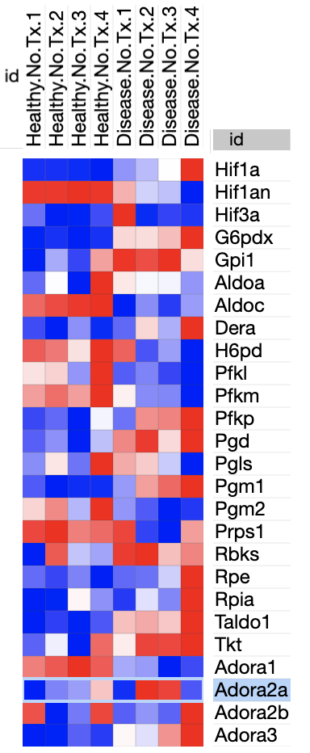

# Tidying and Data Munging

We are using the dplyr package to remove the “Pathways” column, as well as an empty column included in the dataset.

```r
# Drop the columns of the dataframe
metabolism.genes_clean <- metabolism.genes %>%
  select (-c(10,11)) %>%
  gather(Samples, Expression, 2:9) %>%
  separate(Samples, into = c("Health.Status", "Sample.Number"), sep = ".No.Tx.") %>%
  arrange(Gene.Symbol)
```

## Statistical Analyses

```r
# library(broom)

t.test(`Expression`~Health.Status, data=metabolism.genes_clean)
```

```
##
##  Welch Two Sample t-test
##
## data:  Expression by Health.Status
## t = 0.43992, df = 205.89, p-value = 0.6605
## alternative hypothesis: true difference in means is not equal to 0
## 95 percent confidence interval:
##  -21.38384  33.66779
## sample estimates:
## mean in group Disease mean in group Healthy
##              79.12838              72.98640
```

```r
wilcox.test(`Expression`~Health.Status, data=metabolism.genes_clean)
```

```
##
##  Wilcoxon rank sum test with continuity correction
##
## data:  Expression by Health.Status
## W = 5550, p-value = 0.7444
## alternative hypothesis: true location shift is not equal to 0
```

```r
aov(`Expression`~Health.Status, data=metabolism.genes_clean)
```

```
## Call:
##    aov(formula = Expression ~ Health.Status, data = metabolism.genes_clean)
##
## Terms:
##                 Health.Status Residuals
## Sum of Squares         1961.6 2088017.4
## Deg. of Freedom             1       206
##
## Residual standard error: 100.6777
## Estimated effects may be unbalanced
```

```r
kruskal.test(`Expression`~Health.Status, data=metabolism.genes_clean)
```

```
##
##  Kruskal-Wallis rank sum test
##
## data:  Expression by Health.Status
## Kruskal-Wallis chi-squared = 0.10704, df = 1, p-value = 0.7435
```

```r
t.test(Expression ~ Health.Status, data = metabolism.genes_clean)$p.value
```

```
## [1] 0.6604547
```

```r
library(infer)
results <- metabolism.genes_clean %>%
  specify(Expression ~ Health.Status) %>%
  mutate(Expression = as.numeric(Expression)) %>%
  mutate(Health.Status = as.factor(Health.Status)) %>%
  specify(Expression ~ Health.Status) %>%
  hypothesize(null = 'independence') %>%
  generate(reps = 1000, type = 'permute') %>%
  calculate("diff in means", order = c("Healthy", "Disease"))

obs <- metabolism.genes_clean %>%
  mutate(Expression = as.numeric(Expression)) %>%
  mutate(Health.Status = as.factor(Health.Status)) %>%
  specify(Expression ~ Health.Status) %>%
  # hypothesize(null = 'independence') %>%
  calculate("diff in means", order = c("Healthy", "Disease"))

pval <- results %>% get_p_value(obs_stat = obs, direction='two_sided')
pval
```

```
## # A tibble: 1 x 1
##   p_value
##     <dbl>
## 1   0.734
```

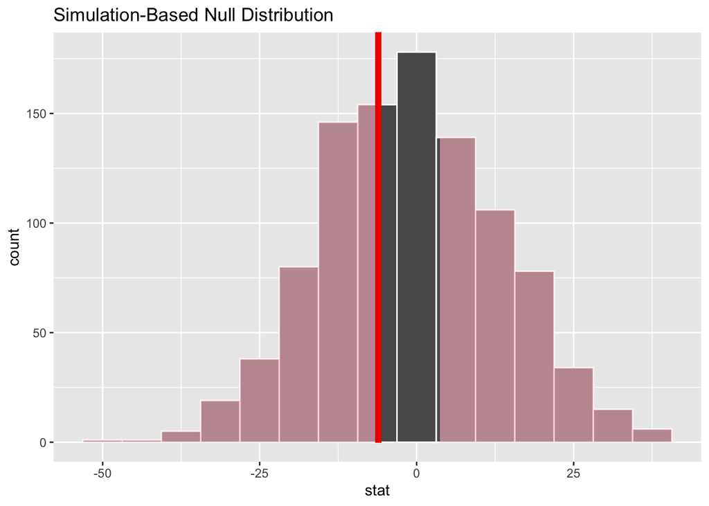

```r
results %>%
  visualize() +
  shade_p_value(obs_stat=obs, direction='two_sided')
```

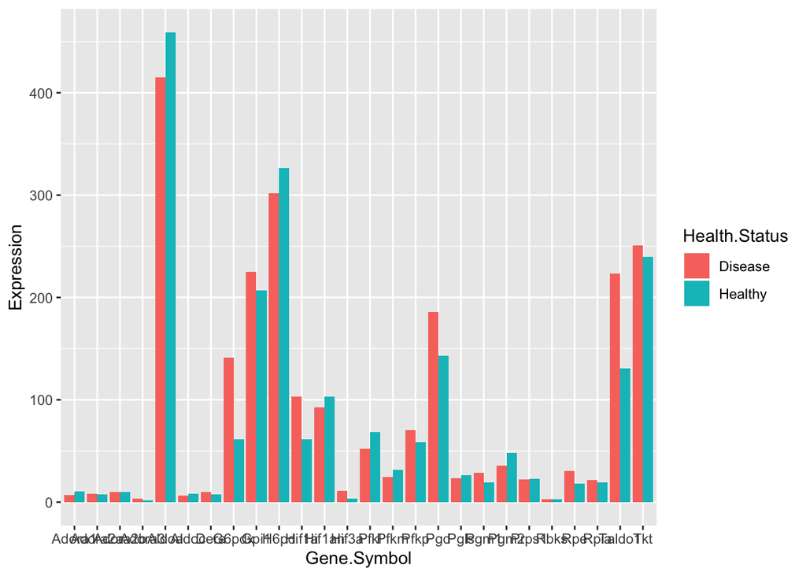

```r
#Graphically represent data
#We will be using the ggplot package. A Manhattan plot would allow better visual representation of gene expression.

(metabolism.genes_graph <- metabolism.genes_clean %>%
 ggplot()+
  geom_bar(mapping = aes(x=Gene.Symbol, y=Expression, fill=Health.Status), stat='identity', position='dodge')
)
```

**References**

Turner, S.D. (2014) **qqman: an R package for visualizing GWAS results using Q-Q and manhattan plots. biorXiv** DOI: 10.1101/005165

Heat map generated using Morpheus from the Broad Institute